# R Notebook

OBJECTIVE: Kerala is a state in the south western part of India. It is one of the most literate states in India and also enjoys the highest Human Development Index compared to other states in India.

The Health Management Information System (HMIS) is an online portal which gathers and displays health related indicators of India. The level of granularity is the subdistrict (the hierarchy can be visualized as country -> state -> district -> sub-district).

For this linear regression exercise, we considered the HMIS indicators for the 292 sub districts (corresponding to 14 districts) of Kerala for the year periods 2014-15 and 2015-16. While the overall HMIS indicators are quite comprehensive, we considered only the child birth related HMIS indicators. In particular, we are interested in understanding the impact of various factors (different independent variables) on the number of babies born with a birth weight less than 2.5 kg (dependent variable) across the sub districts and for the two-time periods.

Data is from #https://data.gov.in/catalog/performance-key-hmis-indicators-across-sub-districts-kerala

```r
    knitr::opts_knit$set(root.dir = normalizePath("/Users/anon/GitHubRepos/CourseFiles/Regression/"))
```

```r
library(data.table)
library(tibble)
library(ggplot2)
library(reshape2)
library(corrplot)
library(MASS)
library(knitr)
```

```r
#Reading the 14 files - only the first 104 columns which correspond to the period from pregnancy
#to birth
data_1 <- fread("Alappuzha.csv", select = c(1:104))
data_2 <- fread("Ernakulam.csv", select = c(1:104))
data_3 <- fread("Idukki.csv", select = c(1:104))
data_4 <- fread("Kannur.csv", select = c(1:104))
data_5 <- fread("Kasaragod.csv", select = c(1:104))
data_6 <- fread("Kollam.csv", select = c(1:104))
data_7 <- fread("Kottayam.csv", select = c(1:104))
data_8 <- fread("KOZHIKKODE.csv", select = c(1:104))
data_9 <- fread("Malappuram.csv", select = c(1:104))
data_10 <- fread("Palakkad.csv", select = c(1:104))
data_11 <- fread("Pathanamthitta.csv", select = c(1:104))
data_12 <- fread("Thiruvananthapuram.csv", select = c(1:104))
data_13 <- fread("Thrissur.csv", select = c(1:104))
data_14 <- fread("Wayanad.csv", select = c(1:104))
```

```r
data_1 <- add_column(data_1, Indicator_no=1, .after = 2)
data_2 <- add_column(data_2, Indicator_no=2, .after = 2)
data_3 <- add_column(data_3, Indicator_no=3, .after = 2)
data_4 <- add_column(data_4, Indicator_no=4, .after = 2)
data_5 <- add_column(data_5, Indicator_no=5, .after = 2)
data_6 <- add_column(data_6, Indicator_no=6, .after = 2)
data_7 <- add_column(data_7, Indicator_no=7, .after = 2)
data_8 <- add_column(data_8, Indicator_no=8, .after = 2)
data_9 <- add_column(data_9, Indicator_no=9, .after = 2)
data_10 <- add_column(data_10, Indicator_no=10, .after = 2)
data_11 <- add_column(data_11, Indicator_no=11, .after = 2)
data_12 <- add_column(data_12, Indicator_no=12, .after = 2)
data_13 <- add_column(data_13, Indicator_no=13, .after = 2)
data_14 <- add_column(data_14, Indicator_no=14, .after = 2)
```

```r
#Combining all the 14 dataframes to one
data_combined <- data.frame(rbind(data_1,data_2,data_3,data_4,data_5,data_6,data_7,data_8,data_9,
                                  data_10,data_11,data_12,data_13,data_14))
```

```r
#Each file has one row which indicates the total values for all subdistricts - removing this
data_combined <- data_combined[-which(data_combined$S.No == "Total"),]
#The data corresponds to two time periods 2014-15 and 2015-16. The features are given for both
#these time periods and is column wise.
#Converting this to a different format - where year (time period) is a new feature and the hmis
# features appear only once with corresponding values for both the time periods
# creating two separate dataframes - one for 14-15 and one for 15-16
data_transform_1516 <- data_combined[,c(2,3,grep("2015.16", colnames(data_combined)))]
data_transform_1516 <- add_column(data_transform_1516, year="2015-16", .after = 1)
```

```r
#removing the string indicating the time period from the column names
# it will also make it possible to combine the two dataframes
names(data_transform_1516) <- gsub(names(data_transform_1516), pattern = "2015.16", replacement = "")
data_transform_1415 <- data_combined[,c(2,3,grep("2014.15", colnames(data_combined)))]
data_transform_1415 <- add_column(data_transform_1415, year="2014-15", .after = 1)
names(data_transform_1415) <- gsub(names(data_transform_1415), pattern = "2014.15", replacement = "")
#combining the two dataframes
data_transform_combined <- rbind(data_transform_1415,data_transform_1516)
```

```r
#Writing this to a csv file to do some more cleaning on the column names
write.csv(data_transform_combined,"hmis_data_cleaned.csv")
```

```r
#Reading the cleaned data
cleaned_data <- read.csv("hmis_data_cleaned_final.csv")
#Removing the rows with target variable NA
cleaned_data <- cleaned_data[-which(is.na(cleaned_data$Perc_Newborns_having_weight_less_than_2.5.kg_to_Newborns_weighed_at_birth)),]
#Removing these columns as they are events during delivery which would have not an impact on
#childs weight
cleaned_data$home_deliveries_attended_by_SBA_trained_Doctor_Nurse <- NULL
cleaned_data$home_deliveries_attended_by_Non_SBA_trained <- NULL
cleaned_data$Mothers_paid_JSY_incentive_for_home_deliveries <- NULL
cleaned_data$Total_Number_of_reported_Still_Births <- NULL
cleaned_data[,grep("Perc",colnames(cleaned_data))] <- NULL
```

```r
## Removing the Indicator column as the subdistricts under INdiactor column are coded as 1 to 14
# under INdicator_no column
cleaned_data$Indicator <- NULL
names(cleaned_data)[grep("conducted",names(cleaned_data), ignore.case = TRUE)] <- gsub("conducted",
      "",names(cleaned_data)[grep("conducted",names(cleaned_data), ignore.case = TRUE)],
      ignore.case = TRUE)
names(cleaned_data)[14] <- "Institutional_deliveries_Public_Pvt"
##Setting the name of the target variable Number_of_Newborns_having_weight_less_than_2.5.kg
##as target
names(cleaned_data)[20] <- "Target"
summary(cleaned_data)
```

```
       X               year      Indicator_no    Total_pregnant_women_registered_ANC
 Min.   :   2.0   2014-15:250   Min.   : 1.000   Min.   :   0
 1st Qu.: 149.0   2015-16:251   1st Qu.: 4.000   1st Qu.: 444
 Median : 295.0                 Median : 8.000   Median :1509
 Mean   : 873.7                 Mean   : 7.559   Mean   :1783
 3rd Qu.:1571.0                 3rd Qu.:11.000   3rd Qu.:2489
 Max.   :3061.0                 Max.   :14.000   Max.   :8065

 Total_registered_within_first_trimester Total_registered_under_JSY
 Min.   :   0                            Min.   :   0
 1st Qu.: 341                            1st Qu.: 194
 Median :1203                            Median : 718
 Mean   :1440                            Mean   : 945
 3rd Qu.:2051                            3rd Qu.:1283
 Max.   :6418                            Max.   :7230

 Total_received_3_ANC_check_ups Booster_given_numbers Total_given_100_IFA_tablets
 Min.   :   0                   Min.   :   0          Min.   :    0
 1st Qu.: 427                   1st Qu.: 615          1st Qu.:  534
 Median :1445                   Median :1113          Median : 1340
 Mean   :1633                   Mean   :1499          Mean   : 1677
 3rd Qu.:2332                   3rd Qu.:2018          3rd Qu.: 2301
 Max.   :6746                   Max.   :8332          Max.   :11699

 Number_having_Hb_level_11_tested_cases Number_having_severe_anaemia_Hb_7_treated_at_institutin
 Min.   :   0.0                         Min.   :  0.000
 1st Qu.:  17.0                         1st Qu.:  0.000
 Median :  79.0                         Median :  0.000
 Mean   : 322.8                         Mean   :  9.223
 3rd Qu.: 339.0                         3rd Qu.:  5.000
 Max.   :5622.0                         Max.   :253.000
                                        NA's   :12
 Total_home_deliveries Deliveries__at_Public_Institutions Institutional_deliveries_Public_Pvt
 Min.   :  0.000       Min.   :    0.0                    Min.   :    0
 1st Qu.:  0.000       1st Qu.:    0.0                    1st Qu.:  179
 Median :  1.000       Median :    0.0                    Median :  884
 Mean   :  4.026       Mean   :  575.1                    Mean   : 1907
 3rd Qu.:  3.000       3rd Qu.:  410.0                    3rd Qu.: 2221
 Max.   :101.000       Max.   :16821.0                    Max.   :29245
 NA's   :113
```

[output cut: 8 more lines]

```
 Number_of_C_section_deliveries__at_private_facilities Total_reported_live_births
 Min.   :   0.0                                        Min.   :    1
 1st Qu.:  80.0                                        1st Qu.:  181
 Median : 338.0                                        Median :  953
 Mean   : 625.9                                        Mean   : 1932
 3rd Qu.: 887.8                                        3rd Qu.: 2235
 Max.   :5743.0                                        Max.   :30077
 NA's   :59
 Number_of_Newborns_weighed_at_birth     Target
 Min.   :    1                       Min.   :   0.0
 1st Qu.:  180                       1st Qu.:  10.0
 Median :  953                       Median :  69.0
 Mean   : 1929                       Mean   : 217.3
 3rd Qu.: 2235                       3rd Qu.: 215.0
 Max.   :30077                       Max.   :5800.0
```

```r
cleaned_data[which(is.na(cleaned_data$Number_having_severe_anaemia_Hb_7_treated_at_institutin)),"Number_having_severe_anaemia_Hb_7_treated_at_institutin"] <-
  median(cleaned_data$Number_having_severe_anaemia_Hb_7_treated_at_institutin, na.rm = TRUE)
cleaned_data[which(is.na(cleaned_data$Total_home_deliveries)),"Total_home_deliveries"] <-
  (cleaned_data[which(is.na(cleaned_data$Total_home_deliveries)),"Total_reported_deliveries"] -
  cleaned_data[which(is.na(cleaned_data$Total_home_deliveries)),"Institutional_deliveries_Public_Pvt"])
cleaned_data <- cleaned_data[-which(is.na(cleaned_data$Number_of_C_section_deliveries__at_private_facilities)),]
```

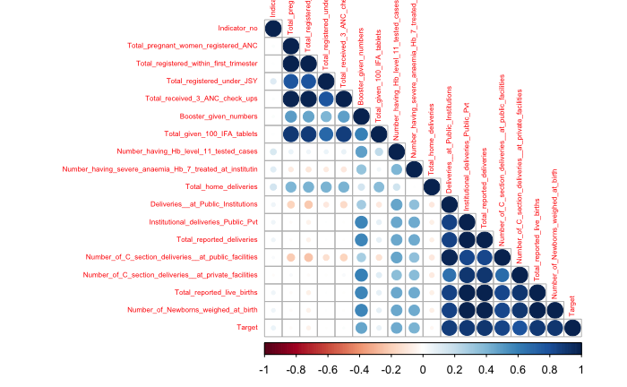

```r
#Correlation plot
corrplot(cor(cleaned_data[,-(1:2)], use = "complete.obs"), type = "lower", tl.cex = 0.5)
```

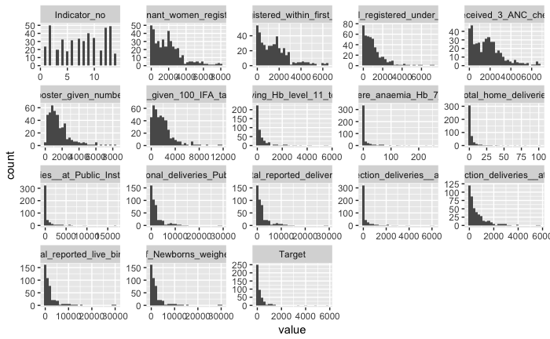

```r
#histogram of all variables
ggplot(melt(cleaned_data[,-1])) + geom_histogram(aes(x = value), bins = 30) + facet_wrap(~variable,scales="free")
```

```r
###Running the model
model_1 <- lm(Target ~ ., data = cleaned_data[,-c(1:2)])
summary(model_1)
```

```
Call:
lm(formula = Target ~ ., data = cleaned_data[, -c(1:2)])

Residuals:
    Min      1Q  Median      3Q     Max
-901.73  -56.30    8.98   54.24 1727.91

Coefficients: (1 not defined because of singularities)
                                                          Estimate Std. Error t value Pr(>|t|)
(Intercept)                                             -1.044e+02  2.363e+01  -4.419 1.26e-05
Indicator_no                                             2.278e+00  2.264e+00   1.006   0.3148
Total_pregnant_women_registered_ANC                     -1.209e-01  5.987e-02  -2.019   0.0441
Total_registered_within_first_trimester                 -7.373e-02  6.845e-02  -1.077   0.2820
Total_registered_under_JSY                              -2.540e-02  1.384e-02  -1.835   0.0672
Total_received_3_ANC_check_ups                           2.323e-01  4.212e-02   5.514 6.09e-08
Booster_given_numbers                                   -7.229e-03  1.253e-02  -0.577   0.5643
Total_given_100_IFA_tablets                              1.812e-02  1.292e-02   1.403   0.1614
Number_having_Hb_level_11_tested_cases                  -1.031e-02  1.810e-02  -0.570   0.5690
Number_having_severe_anaemia_Hb_7_treated_at_institutin  1.613e+00  4.090e-01   3.944 9.36e-05
Total_home_deliveries                                    6.730e-01  1.015e+00   0.663   0.5077
Deliveries__at_Public_Institutions                       2.821e-01  3.573e-02   7.896 2.48e-14
Institutional_deliveries_Public_Pvt                     -1.001e-01  1.024e-01  -0.978   0.3288
Total_reported_deliveries                                       NA         NA      NA       NA
Number_of_C_section_deliveries__at_public_facilities    -3.085e-01  7.664e-02  -4.026 6.73e-05
Number_of_C_section_deliveries__at_private_facilities    1.711e-01  3.598e-02   4.757 2.69e-06
Total_reported_live_births                              -1.985e-01  2.488e-01  -0.798   0.4253
Number_of_Newborns_weighed_at_birth                      3.240e-01  2.177e-01   1.488   0.1375

(Intercept)                                             ***
Indicator_no
Total_pregnant_women_registered_ANC                     *
Total_registered_within_first_trimester
Total_registered_under_JSY                              .
Total_received_3_ANC_check_ups                          ***
Booster_given_numbers
Total_given_100_IFA_tablets
Number_having_Hb_level_11_tested_cases
Number_having_severe_anaemia_Hb_7_treated_at_institutin ***
Total_home_deliveries
Deliveries__at_Public_Institutions                      ***
Institutional_deliveries_Public_Pvt
Total_reported_deliveries
Number_of_C_section_deliveries__at_public_facilities    ***
Number_of_C_section_deliveries__at_private_facilities   ***
Total_reported_live_births
Number_of_Newborns_weighed_at_birth
---
Signif. codes:  0 ‘***’ 0.001 ‘**’ 0.01 ‘*’ 0.05 ‘.’ 0.1 ‘ ’ 1

Residual standard error: 179.4 on 425 degrees of freedom
Multiple R-squared:  0.8763,    Adjusted R-squared:  0.8716
F-statistic: 188.2 on 16 and 425 DF,  p-value: < 2.2e-16
```

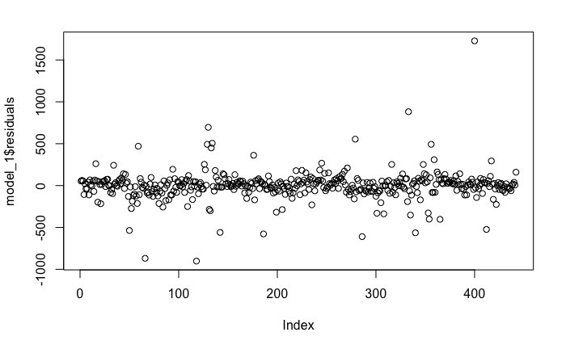

```r
plot(model_1$residuals)
```

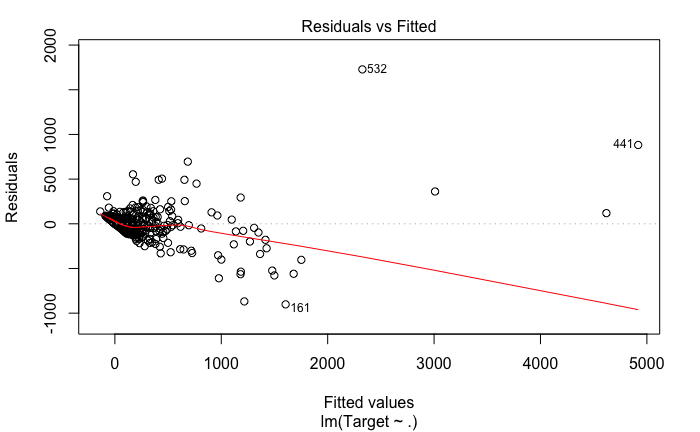

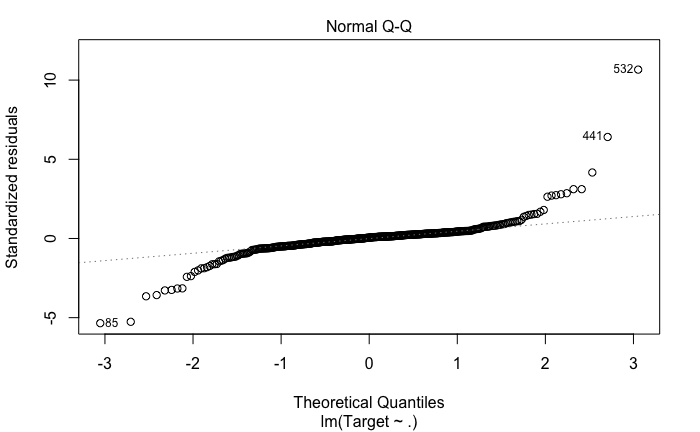

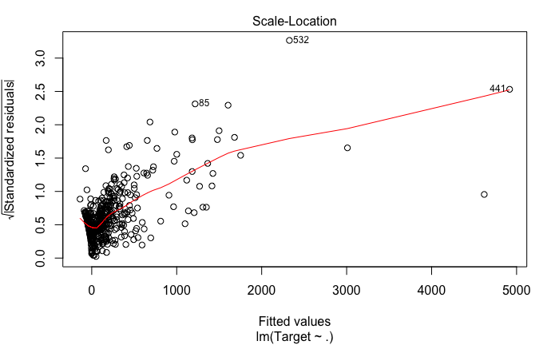

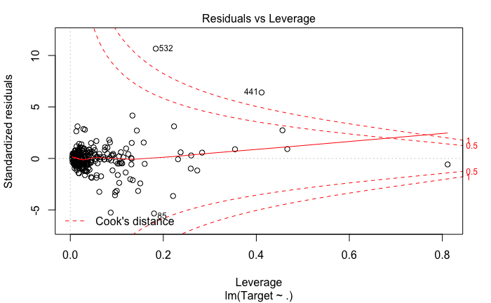

```r
plot(model_1)
```

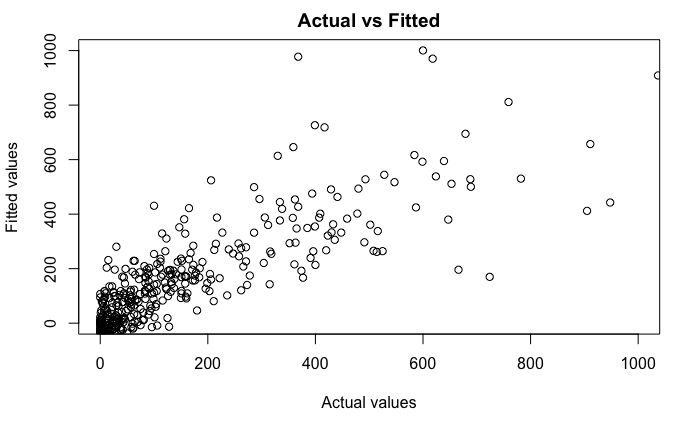

```r
plot(cleaned_data$Target, model_1$fitted.values, xlim=c(0,1000), ylim=c(0,1000), xlab = "Actual values", ylab="Fitted values", main = "Actual vs Fitted")
```

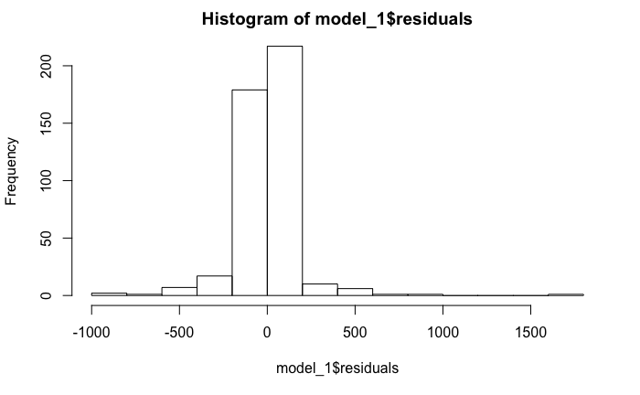

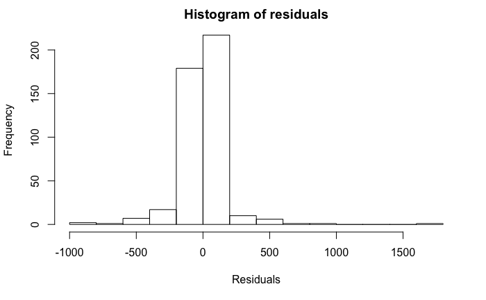

```r
plot(hist(model_1$residuals), main = "Histogram of residuals", xlab="Residuals")
```

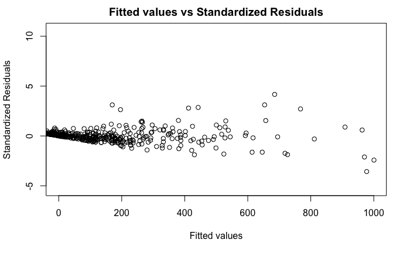

```r
plot(model_1$fitted.values, rstandard(model_1), xlim=c(0,1000), xlab="Fitted values", ylab="Standardized Residuals", main = "Fitted values vs Standardized Residuals")
```

```r
log_cleaned_data <- cleaned_data
log_cleaned_data[,(4:20)] <- sapply(log_cleaned_data[,(4:20)], function(x) log(2+x))
log_cleaned_data$year <- ifelse(log_cleaned_data$year=="2014-15",1,2)
```

```r
model_log_1 <- lm(Target ~ ., data = log_cleaned_data[,-(1:2)])
summary(model_log_1)
```

```
Call:
lm(formula = Target ~ ., data = log_cleaned_data[, -(1:2)])

Residuals:
    Min      1Q  Median      3Q     Max
-3.7371 -0.3069  0.1061  0.4822  1.9663

Coefficients:
                                                         Estimate Std. Error t value Pr(>|t|)
(Intercept)                                             -1.928542   0.367152  -5.253 2.38e-07
Indicator_no                                            -0.003522   0.010161  -0.347  0.72907
Total_pregnant_women_registered_ANC                      0.120825   0.252219   0.479  0.63215
Total_registered_within_first_trimester                 -0.131640   0.274837  -0.479  0.63220
Total_registered_under_JSY                              -0.103977   0.059189  -1.757  0.07969
Total_received_3_ANC_check_ups                           0.047291   0.117788   0.401  0.68826
Booster_given_numbers                                    0.129023   0.068604   1.881  0.06070
Total_given_100_IFA_tablets                             -0.016407   0.048418  -0.339  0.73488
Number_having_Hb_level_11_tested_cases                   0.060596   0.027854   2.175  0.03015
Number_having_severe_anaemia_Hb_7_treated_at_institutin  0.053042   0.043123   1.230  0.21938
Total_home_deliveries                                    0.174939   0.065732   2.661  0.00808
Deliveries__at_Public_Institutions                       0.024073   0.068293   0.352  0.72464
Institutional_deliveries_Public_Pvt                     -0.397567   0.132329  -3.004  0.00282
Total_reported_deliveries                                0.108639   0.445123   0.244  0.80730
Number_of_C_section_deliveries__at_public_facilities     0.050866   0.075944   0.670  0.50336
Number_of_C_section_deliveries__at_private_facilities    0.066085   0.066186   0.998  0.31861
Total_reported_live_births                               0.688030   3.045892   0.226  0.82140
Number_of_Newborns_weighed_at_birth                      0.294719   3.000776   0.098  0.92181

(Intercept)                                             ***
Indicator_no
Total_pregnant_women_registered_ANC
Total_registered_within_first_trimester
Total_registered_under_JSY                              .
Total_received_3_ANC_check_ups
Booster_given_numbers                                   .
Total_given_100_IFA_tablets
Number_having_Hb_level_11_tested_cases                  *
Number_having_severe_anaemia_Hb_7_treated_at_institutin
Total_home_deliveries                                   **
Deliveries__at_Public_Institutions
Institutional_deliveries_Public_Pvt                     **
Total_reported_deliveries
Number_of_C_section_deliveries__at_public_facilities
Number_of_C_section_deliveries__at_private_facilities
Total_reported_live_births
Number_of_Newborns_weighed_at_birth
---
Signif. codes:  0 ‘***’ 0.001 ‘**’ 0.01 ‘*’ 0.05 ‘.’ 0.1 ‘ ’ 1

Residual standard error: 0.7561 on 424 degrees of freedom
Multiple R-squared:  0.8352,    Adjusted R-squared:  0.8286
F-statistic: 126.4 on 17 and 424 DF,  p-value: < 2.2e-16
```

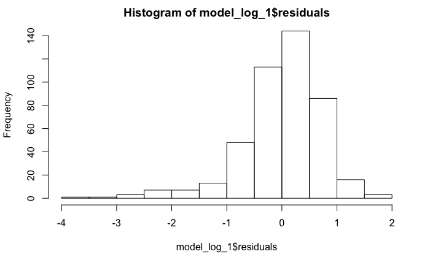

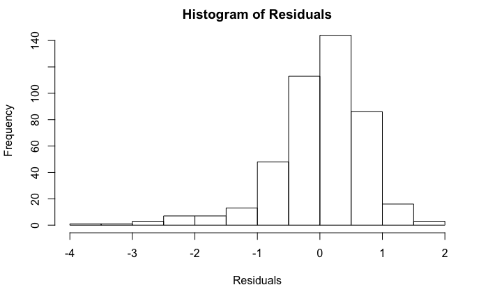

```r
plot(hist(model_log_1$residuals), main = "Histogram of Residuals", xlab = "Residuals")
```

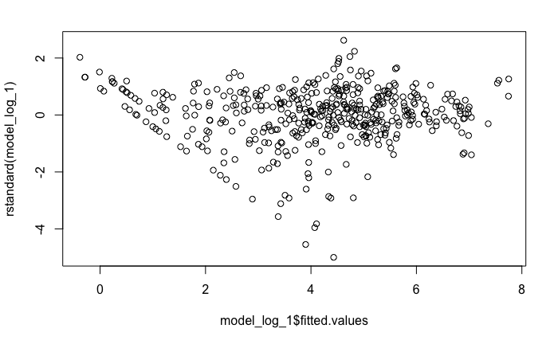

```r
plot(model_log_1$fitted.values, rstandard(model_log_1))
```

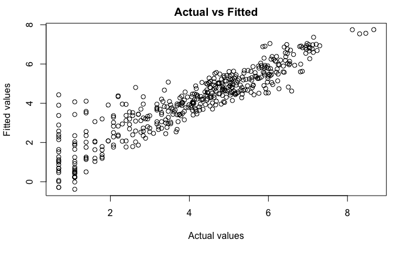

```r
plot(log_cleaned_data$Target,model_log_1$fitted.values, main="Actual vs Fitted", xlab="Actual values", ylab="Fitted values")
```

```r
model_2 <- lm(Target ~ Total_pregnant_women_registered_ANC+Total_registered_under_JSY+
                Total_received_3_ANC_check_ups+Total_given_100_IFA_tablets+Number_having_severe_anaemia_Hb_7_treated_at_institutin+
                Deliveries__at_Public_Institutions+Number_of_C_section_deliveries__at_public_facilities+
                Number_of_C_section_deliveries__at_private_facilities, data = cleaned_data[,-1])
summary(model_2)
```

```
Call:
lm(formula = Target ~ Total_pregnant_women_registered_ANC + Total_registered_under_JSY +
    Total_received_3_ANC_check_ups + Total_given_100_IFA_tablets +
    Number_having_severe_anaemia_Hb_7_treated_at_institutin +
    Deliveries__at_Public_Institutions + Number_of_C_section_deliveries__at_public_facilities +
    Number_of_C_section_deliveries__at_private_facilities, data = cleaned_data[,
    -1])

Residuals:
    Min      1Q  Median      3Q     Max
-914.41  -51.96    7.12   53.99 1680.08

Coefficients:
                                                         Estimate Std. Error t value Pr(>|t|)
(Intercept)                                             -93.58121   15.20794  -6.153 1.73e-09
Total_pregnant_women_registered_ANC                      -0.16123    0.03842  -4.196 3.29e-05
Total_registered_under_JSY                               -0.02392    0.01329  -1.799   0.0727
Total_received_3_ANC_check_ups                            0.21320    0.04060   5.252 2.37e-07
Total_given_100_IFA_tablets                               0.01510    0.01211   1.247   0.2130
Number_having_severe_anaemia_Hb_7_treated_at_institutin   1.69963    0.38010   4.472 9.93e-06
Deliveries__at_Public_Institutions                        0.34242    0.02589  13.227  < 2e-16
Number_of_C_section_deliveries__at_public_facilities     -0.40149    0.06916  -5.805 1.25e-08
Number_of_C_section_deliveries__at_private_facilities     0.22681    0.01576  14.387  < 2e-16

(Intercept)                                             ***
Total_pregnant_women_registered_ANC                     ***
Total_registered_under_JSY                              .
Total_received_3_ANC_check_ups                          ***
Total_given_100_IFA_tablets
Number_having_severe_anaemia_Hb_7_treated_at_institutin ***
Deliveries__at_Public_Institutions                      ***
Number_of_C_section_deliveries__at_public_facilities    ***
Number_of_C_section_deliveries__at_private_facilities   ***
---
Signif. codes:  0 ‘***’ 0.001 ‘**’ 0.01 ‘*’ 0.05 ‘.’ 0.1 ‘ ’ 1

Residual standard error: 180.3 on 433 degrees of freedom
Multiple R-squared:  0.8727,    Adjusted R-squared:  0.8703
F-statistic:   371 on 8 and 433 DF,  p-value: < 2.2e-16
```

.